# Prosper Loan Data exploration

## Preliminary Wrangling

I have obtained dataset consisting of detailed information about Loans provided by Prosper. Dataset consists of nearly 114 thousand observations and 81 features providing specific Loan info. The definitions of each feature is listed in separate file, Prosper Loan Data - Variable definition.

```python
# Import all packages and set plots to be embedded inline
import numpy as np
import pandas as pd
import matplotlib.pyplot as plt
import seaborn as sb
import warnings
warnings.filterwarnings("ignore")

%matplotlib inline
```

```python
# Load dataset and print first few rows
loans=pd.read_csv('prosperloanData.csv')
loans.head()
```

|  | ListingKey | ListingNumber | ListingCreationDate | CreditGrade | Term | LoanStatus | ClosedDate | BorrowerAPR | BorrowerRate | LenderYield | ... | LP_ServiceFees | LP_CollectionFees | LP_GrossPrincipalLoss | LP_NetPrincipalLoss | LP_NonPrincipalRecoverypayments | PercentFunded | Recommendations | InvestmentFromFriendsCount | InvestmentFromFriendsAmount | Investors |
| --- | --- | --- | --- | --- | --- | --- | --- | --- | --- | --- | --- | --- | --- | --- | --- | --- | --- | --- | --- | --- | --- |
| 0 | 1021339766868145413AB3B | 193129 | 2007-08-26 19:09:29.263000000 | C | 36 | Completed | 2009-08-14 00:00:00 | 0.16516 | 0.1580 | 0.1380 | ... | -133.18 | 0.0 | 0.0 | 0.0 | 0.0 | 1.0 | 0 | 0 | 0.0 | 258 |
| 1 | 10273602499503308B223C1 | 1209647 | 2014-02-27 08:28:07.900000000 | NaN | 36 | Current | NaN | 0.12016 | 0.0920 | 0.0820 | ... | 0.00 | 0.0 | 0.0 | 0.0 | 0.0 | 1.0 | 0 | 0 | 0.0 | 1 |
| 2 | 0EE9337825851032864889A | 81716 | 2007-01-05 15:00:47.090000000 | HR | 36 | Completed | 2009-12-17 00:00:00 | 0.28269 | 0.2750 | 0.2400 | ... | -24.20 | 0.0 | 0.0 | 0.0 | 0.0 | 1.0 | 0 | 0 | 0.0 | 41 |
| 3 | 0EF5356002482715299901A | 658116 | 2012-10-22 11:02:35.010000000 | NaN | 36 | Current | NaN | 0.12528 | 0.0974 | 0.0874 | ... | -108.01 | 0.0 | 0.0 | 0.0 | 0.0 | 1.0 | 0 | 0 | 0.0 | 158 |
| 4 | 0F023589499656230C5E3E2 | 909464 | 2013-09-14 18:38:39.097000000 | NaN | 36 | Current | NaN | 0.24614 | 0.2085 | 0.1985 | ... | -60.27 | 0.0 | 0.0 | 0.0 | 0.0 | 1.0 | 0 | 0 | 0.0 | 20 |

5 rows × 81 columns

```python
# High-level overview of data shape and composition
loans.shape
```

```
(113937, 81)
```

```python
pd.set_option('display.max_columns', None)
```

```python
# Check types of each rows
loans.dtypes
```

```
ListingKey                      object
ListingNumber                    int64
ListingCreationDate             object
CreditGrade                     object
Term                             int64
                                ...
PercentFunded                  float64
Recommendations                  int64
InvestmentFromFriendsCount       int64
InvestmentFromFriendsAmount    float64
Investors                        int64
Length: 81, dtype: object
```

```python
# Null review
sort=loans.isnull().sum()
sort.sort_values(ascending=False)
```

```
GroupKey                         100596
LoanFirstDefaultedCycleNumber     96985
ScorexChangeAtTimeOfListing       95009
ProsperPrincipalOutstanding       91852
ProsperPrincipalBorrowed          91852
                                  ...
IncomeRange                           0
IncomeVerifiable                      0
StatedMonthlyIncome                   0
LoanKey                               0
Investors                             0
Length: 81, dtype: int64
```

### What is the structure of your dataset?

The Loan dataset consists of 113,937 observations and 81 variables. It seems that the dataset includes null values, but those columns will not be used for analysis and visualization purposes.

### What is/are the main feature(s) of interest in your dataset?

In order to acquaint myself with the dataset I decided to focus on two main parts, as follows:

- **Lender area** (Term conditions, Loan status, Lender Yield, Rating/Score, Loan original amount, Listing categories);
- **Borrower area** (Borrower Rate/APR, Borrower State, Employment status, Employment status duration, Income Range, Debt to Income Ratio, Recommendations).

### What features in the dataset do you think will help support your investigation into your feature(s) of interest?

- I expect that Borrower rate will have negative correlation with Loan amount (the higher Loan Amount, the lower Borrower rate up to certain limit).
- I expect that the reason for why loan is taken determine how large Loan amount will be.
- I expect that high income range clients obtain higher Loan Amount.
- I expect that lower Loans are agreed for shorter period and higher Loans are agreed for longer period of time.

## Univariate Exploration

In order to prepare data for further analysis, I will familiarize myself with the dataset provided. I will plot variables specific for Lender and for Borrower to get an understanding of the data, while searching for any unusual items, distributions or items which require cleaning.

### Lender area

##### Term conditions

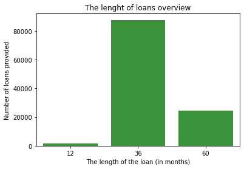

```python
# Loan overview based on TERM CONDITIONS
base_color=sb.color_palette()[2]
sb.countplot(data=loans, x='Term', color=base_color)

plt.xlabel('The length of the loan (in months)')
plt.ylabel('Number of loans provided')
plt.title('The lenght of loans overview');
```

**Answer:** The lenghth of loans consisting of only 3 possibilities as 12 months, 36 months and 60 months. The most loans provided are for period of 36 months.

##### Loan status

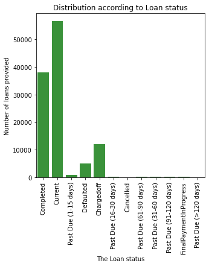

```python
# LOAN STATUS overview
# The current status of the loan: Cancelled,  Chargedoff, Completed,
# Current, Defaulted, FinalPaymentInProgress, PastDue (The PastDue status will be accompanied by a delinquency bucket (analysed later on)).

plt.figure(figsize=[5,5])
sb.countplot(data=loans, x='LoanStatus', color=base_color)

plt.xticks(rotation=90)
plt.xlabel('The Loan status')
plt.ylabel('Number of loans provided')
plt.title('Distribution according to Loan status');
```

**Answer:** The Loan status overview seems reasonable, no unusual items noticed.

##### Lender Yield

```python
# Preparation for LENDER YIELD review
loans[ 'LenderYield'].describe()
```

```
count    113937.000000
mean          0.182701
std           0.074516
min          -0.010000
25%           0.124200
50%           0.173000
75%           0.240000
max           0.492500
Name: LenderYield, dtype: float64
```

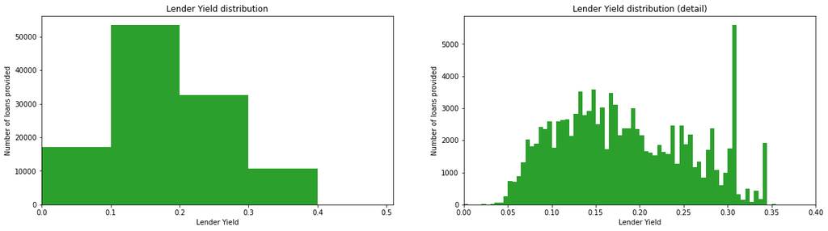

```python
# LENDER YIELD distribution using histogram

plt.figure(figsize=[20,5])

plt.subplot(1,2,1)
bin_size1=0.1
bins1=np.arange(0, (loans['LenderYield'].max())+bin_size1, bin_size1)
plt.hist(data=loans, x='LenderYield', bins=bins1, color=base_color)
plt.xlim((0,0.51))
plt.xlabel('Lender Yield')
plt.ylabel('Number of loans provided')
plt.title('Lender Yield distribution');

plt.subplot(1,2,2) # close review of distribution using different bin and xlim
bin_size=0.005
bins=np.arange(0, (loans['LenderYield'].max())+bin_size, bin_size)
plt.hist(data=loans, x='LenderYield', bins=bins, color=base_color)
plt.xlim((0, 0.4))
plt.xlabel('Lender Yield')
plt.ylabel('Number of loans provided')
plt.title('Lender Yield distribution (detail)');
```

**Answer:** The Lender yield on the loan is equal to the interest rate on the loan less the servicing fee. I see that it is slightly right skewed. It has noticeable spike slightly above 0.3. As it is not possible to more information without further detail analysis, I will continue with this analysis in Part III.

##### Prosper Rating, Credit Grade, Prosper Score

```python
# Convert Prosper Ratings into ordered categorical types
ordinal_var_dict = {'CreditGrade': ['AA', 'A', 'B', 'C', 'D', 'E', 'HR', 'NC']}

for var in ordinal_var_dict:
    ordered_var = pd.api.types.CategoricalDtype(ordered = True,
                                                categories = ordinal_var_dict[var])
    loans[var] = loans[var].astype(ordered_var)
```

```python
# Preparation for Prosper rating review
loans['ProsperRating (numeric)'].value_counts()
```

```
4.0    18345
5.0    15581
6.0    14551
3.0    14274
2.0     9795
1.0     6935
7.0     5372
Name: ProsperRating (numeric), dtype: int64
```

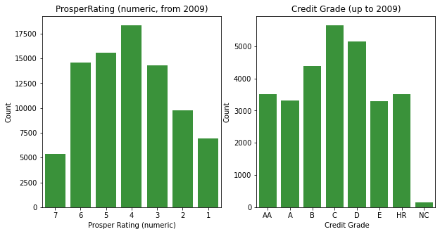

```python
# PROSPER RATING and CREDIT GRADE overview

plt.figure(figsize=[10,5])

# The  Prosper Rating assigned at the time the listing
# was created: 0 - N/A, 1 - HR, 2 - E, 3 - D, 4 - C, 5 - B, 6 - A, 7 - AA.  Applicable for loans originated after July 2009.
plt.subplot(1,2,1)

sb.countplot(data=loans, x='ProsperRating (numeric)', color=base_color, order=[7, 6, 5, 4, 3, 2, 1])

plt.xlabel('Prosper Rating (numeric)')
plt.ylabel('Count')
plt.title('ProsperRating (numeric, from 2009)')

# The Credit rating that was assigned at the time the listing went live.
# Applicable for listings pre-2009 period and will only be populated for those listings.
plt.subplot(1,2,2)
sb.countplot(data=loans, x='CreditGrade', color=base_color)
plt.xlabel(' Credit Grade')
plt.ylabel('Count')
plt.title('Credit Grade (up to 2009)');
```

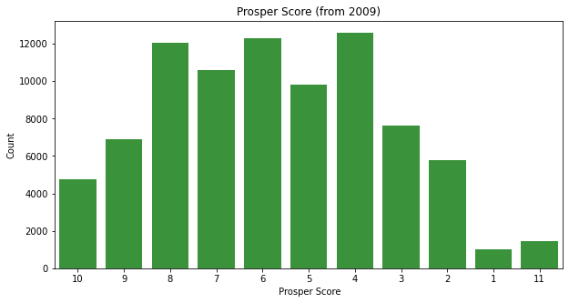

```python
# PROSPER SCORE overview

# A custom risk score built using historical Prosper data.
# The score ranges from 1-10, with 10 being the best, or lowest risk score.  Applicable for loans originated after July 2009.
plt.figure(figsize=[10,5])
sb.countplot(data=loans, x='ProsperScore', color=base_color, order=[10,9,8,7,6,5,4,3,2,1,11])
plt.xlabel(' Prosper Score')
plt.ylabel('Count')
plt.title('Prosper Score (from 2009)');
```

```python
# Filter only those items which has rating out of specific range (1-10), in this case 11
filter_wrong=loans['ProsperScore']==11
filter_wrong_score=loans.loc[filter_wrong, :]
filter_wrong_score
```

|  | ListingKey | ListingNumber | ListingCreationDate | CreditGrade | Term | LoanStatus | ClosedDate | BorrowerAPR | BorrowerRate | LenderYield | EstimatedEffectiveYield | EstimatedLoss | EstimatedReturn | ProsperRating (numeric) | ProsperRating (Alpha) | ProsperScore | ListingCategory (numeric) | BorrowerState | Occupation | EmploymentStatus | EmploymentStatusDuration | IsBorrowerHomeowner | CurrentlyInGroup | GroupKey | DateCreditPulled | CreditScoreRangeLower | CreditScoreRangeUpper | FirstRecordedCreditLine | CurrentCreditLines | … |
| --- | --- | --- | --- | --- | --- | --- | --- | --- | --- | --- | --- | --- | --- | --- | --- | --- | --- | --- | --- | --- | --- | --- | --- | --- | --- | --- | --- | --- | --- | --- |
| 9 | 0F043596202561788EA13D5 | 1023355 | 2013-12-02 10:43:39.117000000 | NaN | 36 | Current | NaN | 0.07620 | 0.0629 | 0.0529 | 0.05221 | 0.0099 | 0.04231 | 7.0 | AA | 11.0 | 7 | IL | Food Service | Employed | 269.0 | True | False | NaN | 2013-12-02 10:43:39 | 820.0 | 839.0 | 1993-04-01 00:00:00 | 17.0 | … |
| 69 | 0F37360159310530849DA23 | 1162592 | 2014-01-25 12:07:54.537000000 | NaN | 60 | Current | NaN | 0.13636 | 0.1139 | 0.1039 | 0.09989 | 0.0349 | 0.06499 | 6.0 | A | 11.0 | 1 | IL | Investor | Self-employed | 12.0 | True | True | NaN | 2014-01-25 11:51:41 | 700.0 | 719.0 | 1995-08-01 00:00:00 | 5.0 | … |
| 158 | 108E36027739898797E47EC | 1202850 | 2014-02-12 16:31:25.340000000 | NaN | 36 | Current | NaN | 0.09469 | 0.0809 | 0.0709 | 0.06919 | 0.0199 | 0.04929 | 7.0 | AA | 11.0 | 6 | OR | Tradesman - Mechanic | Employed | 22.0 | False | False | NaN | 2014-02-12 16:31:27 | 700.0 | 719.0 | 1999-05-28 00:00:00 | 9.0 | … |
| 224 | 2F293599751524472C82DEA | 1130508 | 2014-01-10 07:24:44.853000000 | NaN | 36 | Current | NaN | 0.13799 | 0.1099 | 0.0999 | 0.09628 | 0.0324 | 0.06388 | 6.0 | A | 11.0 | 1 | WI | Sales - Commission | Employed | 114.0 | True | False | NaN | 2014-01-10 07:24:47 | 720.0 | 739.0 | 1995-10-02 00:00:00 | 16.0 | … |
| 236 | 11D335932344051959C94C6 | 973657 | 2013-11-02 01:29:09.810000000 | NaN | 36 | Current | NaN | 0.06726 | 0.0605 | 0.0505 | 0.05001 | 0.0074 | 0.04261 | 7.0 | AA | 11.0 | 1 | OR | Tradesman - Mechanic | Employed | 105.0 | True | False | NaN | 2013-11-02 01:29:12 | 820.0 | 839.0 | 1998-12-08 00:00:00 | 11.0 | … |
| ... | ... | ... | ... | ... | ... | ... | ... | ... | ... | ... | ... | ... | ... | ... | ... | ... | ... | ... | ... | ... | ... | ... | ... | ... | ... | ... | ... | ... | ... | … |
| 113762 | E41735941348970874153D6 | 1040844 | 2013-11-18 17:55:25.090000000 | NaN | 60 | Current | NaN | 0.13636 | 0.1139 | 0.1039 | 0.09989 | 0.0349 | 0.06499 | 6.0 | A | 11.0 | 20 | NY | Other | Employed | 41.0 | True | False | NaN | 2013-11-18 17:55:27 | 740.0 | 759.0 | 1999-09-29 00:00:00 | 10.0 | … |
| 113784 | CF4C3593704223935C8DEF5 | 1021056 | 2013-11-05 20:51:45.540000000 | NaN | 36 | Current | NaN | 0.12691 | 0.0990 | 0.0890 | 0.08643 | 0.0249 | 0.06153 | 6.0 | A | 11.0 | 1 | CA | Other | Employed | 158.0 | True | False | NaN | 2013-11-05 20:51:48 | 720.0 | 739.0 | 1981-05-11 00:00:00 | 10.0 | … |
| 113855 | DF45360176809914475660A | 1211163 | 2014-02-15 18:43:57.650000000 | NaN | 36 | Current | NaN | 0.14751 | 0.1189 | 0.1089 | 0.10446 | 0.0374 | 0.06706 | 6.0 | A | 11.0 | 3 | NY | Food Service Management | Full-time | 89.0 | False | False | NaN | 2014-02-15 18:43:59 | 640.0 | 659.0 | 2009-12-28 00:00:00 | 6.0 | … |
| 113881 | E2C73590325077098CCF6F5 | 967344 | 2013-10-09 10:09:28.530000000 | NaN | 60 | Current | NaN | 0.19681 | 0.1730 | 0.1630 | 0.15264 | 0.0674 | 0.08524 | 4.0 | C | 11.0 | 7 | CO | Professional | Employed | 37.0 | True | False | NaN | 2013-10-09 10:09:31 | 660.0 | 679.0 | 2000-06-06 00:00:00 | 12.0 | … |
| 113912 | C98A3597264633447D66DF9 | 1083677 | 2013-12-16 16:36:00.990000000 | NaN | 36 | Current | NaN | 0.06726 | 0.0605 | 0.0505 | 0.05000 | 0.0074 | 0.04260 | 7.0 | AA | 11.0 | 2 | MN | Scientist | Employed | 102.0 | False | True | NaN | 2013-12-16 16:36:03 | 800.0 | 819.0 | 1999-04-23 00:00:00 | 10.0 | … |

1456 rows × 81 columns

**Answer:** Prosper Score includes score '11' what seems to be mistake as the range is from 1 to 10. Wrong score has 1 456 observations, representing 1.3% of all data. As it is not significant amount, I will not remove data. Further more, it might be human-error, remaining information seems to be allright.

##### Loan original amount

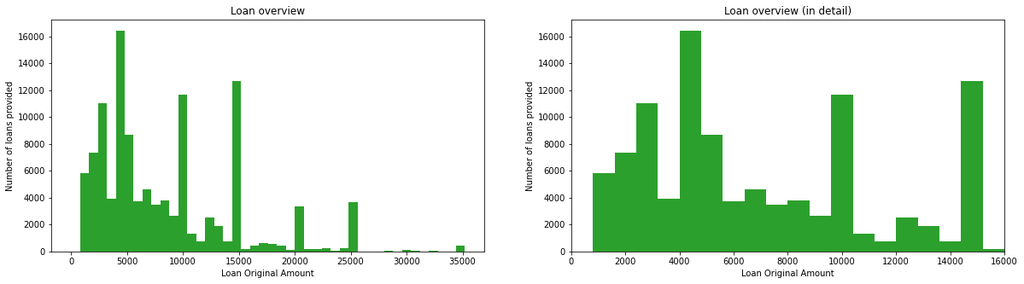

```python
# Loan Original Amount plot using histogram
plt.figure(figsize=[20,5])

plt.subplot(1,2,1)
bin_size1=800
bins1=np.arange(0, (loans['LoanOriginalAmount'].max())+bin_size1, bin_size1)
plt.hist(data=loans, x='LoanOriginalAmount', bins=bins1, color=base_color)

plt.xlabel('Loan Original Amount')
plt.ylabel('Number of loans provided')
plt.title('Loan overview');


# LoanOriginalAmount overview in detail
plt.subplot(1,2,2)
bin_size1=800
bins1=np.arange(0, (loans['LoanOriginalAmount'].max())+bin_size1, bin_size1)
plt.hist(data=loans, x='LoanOriginalAmount', bins=bins1, color=base_color)

plt.xlim((0,16000))
plt.xlabel('Loan Original Amount')
plt.ylabel('Number of loans provided')
plt.title('Loan overview (in detail)');
```

**Answer:** The distribution of Loan amount is right skewed with several noticeable spikes in frequency at the bars (around 5,000; 10,000 and 15,000). It might represent standard loan amount. Such assumption may be confirmed later on during analysis.

##### Listing categories

```python
# LISTING CATEGORY overview

# The category of the listing that the borrower selected when posting their listing: 0 - Not Available, 1 - Debt Consolidation,
#2 - Home Improvement, 3 - Business, 4 - Personal Loan, 5 - Student Use, 6 - Auto, 7- Other, 8 - Baby&Adoption, 9 - Boat,
#10 - Cosmetic Procedure, 11 - Engagement Ring, 12 - Green Loans,
#13 - Household Expenses, 14 - Large Purchases, 15 - Medical/Dental, 16 - Motorcycle, 17 - RV, 18 - Taxes, 19 - Vacation, 20 - Wedding Loans

# Define function to create new column with listing categories written in text in order to prepare base for Bar chart
def list_categ_text(x):
    if (x ==0) :
        return 'Not Available'
    elif (x == 1):
        return 'Debt Consolidation'
    elif (x == 2):
        return 'Home Improvement'
    elif (x == 3):
        return 'Business'
    elif (x == 4):
        return 'Personal Loan'
    elif (x == 5):
        return 'Student Use'
    elif (x == 6):
        return 'Auto'
    elif (x == 7):
        return 'Other'
    elif (x == 8):
        return 'Baby&Adoption'
    elif (x == 9):
        return 'Boat'
    elif (x == 10):
        return 'Cosmetic Procedure'
    elif (x == 11):
        return 'Engagement Ring'
    elif (x == 12):
        return 'Green Loans'
    elif (x == 13):
        return 'Household Expenses'
    elif (x == 14):
        return 'Large Purchases'
    elif (x == 15):
        return 'Medical/Dental'
    elif (x == 16):
        return 'Motorcycle'
    elif (x == 17):
        return 'RV'
    elif (x == 18):
        return 'Taxes'
    elif (x == 19):
        return 'Vacation'
    else:
        return 'Wedding Loans'

loans['ListingCategory_text'] = loans['ListingCategory (numeric)'].apply(list_categ_text)
loans.head(2)
```

|  | ListingKey | ListingNumber | ListingCreationDate | CreditGrade | Term | LoanStatus | ClosedDate | BorrowerAPR | BorrowerRate | LenderYield | EstimatedEffectiveYield | EstimatedLoss | EstimatedReturn | ProsperRating (numeric) | ProsperRating (Alpha) | ProsperScore | ListingCategory (numeric) | BorrowerState | Occupation | EmploymentStatus | EmploymentStatusDuration | IsBorrowerHomeowner | CurrentlyInGroup | GroupKey | DateCreditPulled | CreditScoreRangeLower | CreditScoreRangeUpper | FirstRecordedCreditLine | CurrentCreditLines | … |
| --- | --- | --- | --- | --- | --- | --- | --- | --- | --- | --- | --- | --- | --- | --- | --- | --- | --- | --- | --- | --- | --- | --- | --- | --- | --- | --- | --- | --- | --- | --- |
| 0 | 1021339766868145413AB3B | 193129 | 2007-08-26 19:09:29.263000000 | C | 36 | Completed | 2009-08-14 00:00:00 | 0.16516 | 0.158 | 0.138 | NaN | NaN | NaN | NaN | NaN | NaN | 0 | CO | Other | Self-employed | 2.0 | True | True | NaN | 2007-08-26 18:41:46.780000000 | 640.0 | 659.0 | 2001-10-11 00:00:00 | 5.0 | … |
| 1 | 10273602499503308B223C1 | 1209647 | 2014-02-27 08:28:07.900000000 | NaN | 36 | Current | NaN | 0.12016 | 0.092 | 0.082 | 0.0796 | 0.0249 | 0.0547 | 6.0 | A | 7.0 | 2 | CO | Professional | Employed | 44.0 | False | False | NaN | 2014-02-27 08:28:14 | 680.0 | 699.0 | 1996-03-18 00:00:00 | 14.0 | … |

```python
# Set order as parameter in plot code
order_category=loans['ListingCategory_text'].value_counts().index
```

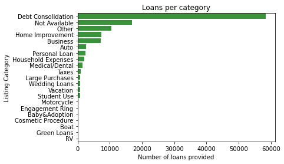

```python
# Bar chart for LOAN LISTING CATEGORIES
sb.countplot(data=loans, y='ListingCategory_text', color=base_color, order=order_category)

plt.xlabel('Number of loans provided')
plt.ylabel('Listing Category')
plt.title('Loans per category');
```

```python
# Removal of Not Available listing category from the colum
filter_nan=loans['ListingCategory_text']=='Not Available'
loans_without_nan=loans.loc[~filter_nan, :]
loans_without_nan.head(2)
```

|  | ListingKey | ListingNumber | ListingCreationDate | CreditGrade | Term | LoanStatus | ClosedDate | BorrowerAPR | BorrowerRate | LenderYield | EstimatedEffectiveYield | EstimatedLoss | EstimatedReturn | ProsperRating (numeric) | ProsperRating (Alpha) | ProsperScore | ListingCategory (numeric) | BorrowerState | Occupation | EmploymentStatus | EmploymentStatusDuration | IsBorrowerHomeowner | CurrentlyInGroup | GroupKey | DateCreditPulled | CreditScoreRangeLower | CreditScoreRangeUpper | FirstRecordedCreditLine | CurrentCreditLines | … |
| --- | --- | --- | --- | --- | --- | --- | --- | --- | --- | --- | --- | --- | --- | --- | --- | --- | --- | --- | --- | --- | --- | --- | --- | --- | --- | --- | --- | --- | --- | --- |
| 1 | 10273602499503308B223C1 | 1209647 | 2014-02-27 08:28:07.900000000 | NaN | 36 | Current | NaN | 0.12016 | 0.0920 | 0.0820 | 0.0796 | 0.0249 | 0.0547 | 6.0 | A | 7.0 | 2 | CO | Professional | Employed | 44.0 | False | False | NaN | 2014-02-27 08:28:14 | 680.0 | 699.0 | 1996-03-18 00:00:00 | 14.0 | … |
| 3 | 0EF5356002482715299901A | 658116 | 2012-10-22 11:02:35.010000000 | NaN | 36 | Current | NaN | 0.12528 | 0.0974 | 0.0874 | 0.0849 | 0.0249 | 0.0600 | 6.0 | A | 9.0 | 16 | GA | Skilled Labor | Employed | 113.0 | True | False | NaN | 2012-10-22 11:02:32 | 800.0 | 819.0 | 1983-02-28 00:00:00 | 5.0 | … |

```python
# Set order as parameter in plot code
# Do not plot low-value categories
order_without_nan=loans_without_nan['ListingCategory_text'].value_counts()[0:13]
order_without_nan
```

```
Debt Consolidation    58308
Other                 10494
Home Improvement       7433
Business               7189
Auto                   2572
Personal Loan          2395
Household Expenses     1996
Medical/Dental         1522
Taxes                   885
Large Purchases         876
Wedding Loans           771
Vacation                768
Student Use             756
Name: ListingCategory_text, dtype: int64
```

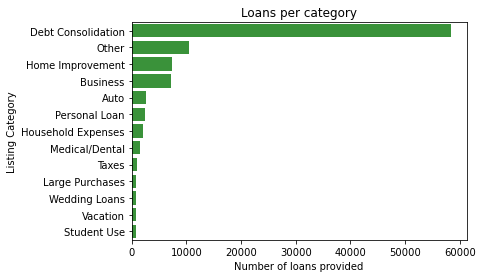

```python
# Plot Bar chart without Not Available listing category and Low-value categories
sb.countplot(data=loans_without_nan, y='ListingCategory_text', color=base_color, order=order_without_nan.index)

plt.xlabel('Number of loans provided')
plt.ylabel('Listing Category')
plt.title('Loans per category');
```

**Answer:**

- As Loan categories were represented by numbers, I decided to create new column 'ListingCategory_text'and assign each observation text label, instead of number.
- The data includes around 17thousand observations (around 15%) with not available information regarding to Listing category. I will not remove them from dataset, as I believe that it is only human-error, I assume that remaining information seem appropriate and needed for further analysis.
- Furthermore, the dataset includes categories with less than 700 observations per each category. I decided not to remove those observations from dataset, but I will not plot them via graph, due to their small amount.

### Borrower

##### Borrower APR, Borrower Rate

```python
# Preparation for BORROWER APR and BORROWER RATE review
loans[['BorrowerAPR', 'BorrowerRate']].describe()
```

|  | BorrowerAPR | BorrowerRate |
| --- | --- | --- |
| count | 113912.000000 | 113937.000000 |
| mean | 0.218828 | 0.192764 |
| std | 0.080364 | 0.074818 |
| min | 0.006530 | 0.000000 |
| 25% | 0.156290 | 0.134000 |
| 50% | 0.209760 | 0.184000 |
| 75% | 0.283810 | 0.250000 |
| max | 0.512290 | 0.497500 |

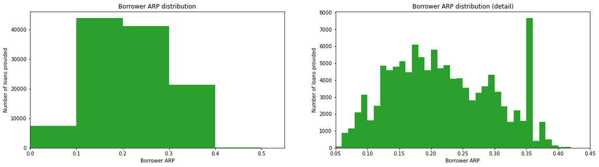

```python
# BORROWER ARP review using barchart

plt.figure(figsize=[20,5])

plt.subplot(1,2,1)
bin_size1=0.1
bins1=np.arange(0, (loans['BorrowerAPR'].max())+bin_size1, bin_size1)
plt.hist(data=loans, x='BorrowerAPR', bins=bins1, color=base_color)
plt.xlim((0,0.55))
plt.xlabel('Borrower ARP')
plt.ylabel('Number of loans provided')
plt.title('Borrower ARP distribution');

plt.subplot(1,2,2) # close review of distribution using different bin and xlim
bin_size=0.01
bins=np.arange(0, (loans['BorrowerAPR'].max())+bin_size, bin_size)
plt.hist(data=loans, x='BorrowerAPR', bins=bins, color=base_color)
plt.xlim((0.05, 0.45))
plt.xlabel('Borrower ARP')
plt.ylabel('Number of loans provided')
plt.title('Borrower ARP distribution (detail)');
```

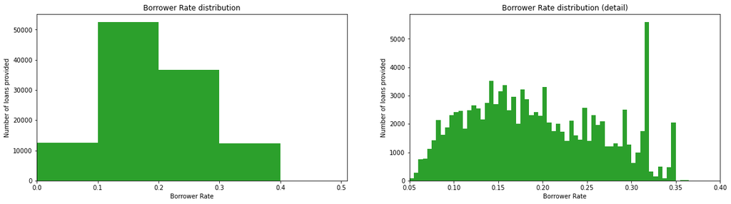

```python
# BORROWER RATE review using bar chart

plt.figure(figsize=[20,5])

plt.subplot(1,2,1)
bin_size1=0.1
bins1=np.arange(0, (loans['BorrowerRate'].max())+bin_size1, bin_size1)
plt.hist(data=loans, x='BorrowerRate', bins=bins1, color=base_color)
plt.xlim((0,0.51))
plt.xlabel('Borrower Rate')
plt.ylabel('Number of loans provided')
plt.title('Borrower Rate distribution');

plt.subplot(1,2,2) # close review of distribution using different bin and xlim
bin_size=0.005
bins=np.arange(0, (loans['BorrowerRate'].max())+bin_size, bin_size)
plt.hist(data=loans, x='BorrowerRate', bins=bins, color=base_color)
plt.xlim((0.05, 0.40))
plt.xlabel('Borrower Rate')
plt.ylabel('Number of loans provided')
plt.title('Borrower Rate distribution (detail)');
```

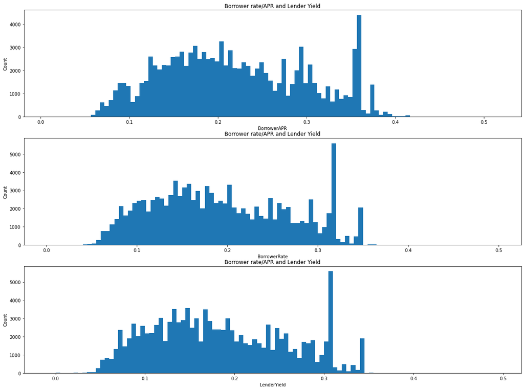

```python
# In order to get better overview, I plotted all three graphs together (Borrower APR, Borrower Rate and Lender Yield)
fig, ax = plt.subplots(nrows=3, figsize = [20,15])

variables = ['BorrowerAPR', 'BorrowerRate', 'LenderYield']
titles = ['BorrowerAPR', 'BorrowerRate', 'LenderYield']
for i in range(len(variables)):
    var = variables[i]
    bins = np.arange(min(loans[var]), max(loans[var])+0.005, 0.005)
    ax[i].hist(data = loans, x = var, bins = bins)
    ax[i].set_xlabel('{}'.format(var))
    ax[i].set_ylabel('{}'.format('Count'))
    ax[i].set_title('{}'.format('Borrower rate/APR and Lender Yield'))




plt.show()
```

##### Borrower State

```python
# Preparation for plotting
order_state=loans['BorrowerState'].value_counts().index
```

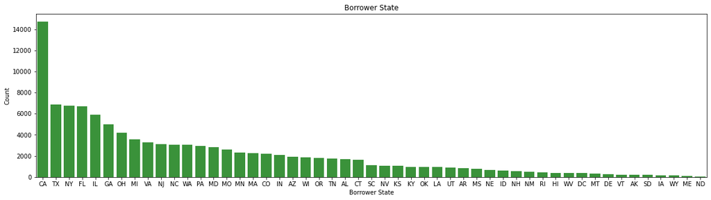

```python
# Plot Bar chart to get overview from which state most Borrower come from
plt.figure(figsize=[20,5])
sb.countplot(data=loans, x='BorrowerState', color=base_color, order=order_state)

plt.xlabel('Borrower State')
plt.ylabel('Count')
plt.title('Borrower State');
```

**Answer:** More that 14,000 loans were borrowed in California. There is no mix of shortcuts and full name of states, therefore, no further cleaning is needed.

##### Employment status

```python
# Preparation for Employment status review
order_empl_status=loans['EmploymentStatus'].value_counts().index
```

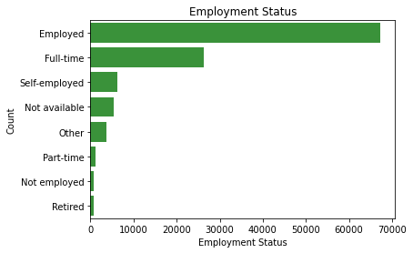

```python
# Review of EMPLOYMENT STATUS
# The employment status of the borrower at the time they posted the listing.

sb.countplot(data=loans, y='EmploymentStatus', color=base_color, order=order_empl_status)

plt.xlabel('Employment Status')
plt.ylabel('Count')
plt.title('Employment Status');
```

**Answer:** I noticed certain amount of observations with not available data. There is also confusion regarding to 'Employed' and for example 'Full-time', 'Part-time'. Such name may cover also other categories within the graph. It only gives us indication, that loans in majority were provided to borrowers with job. I will not use this variable in further analysis, therefore no cleaning is required.

##### Employment status duration

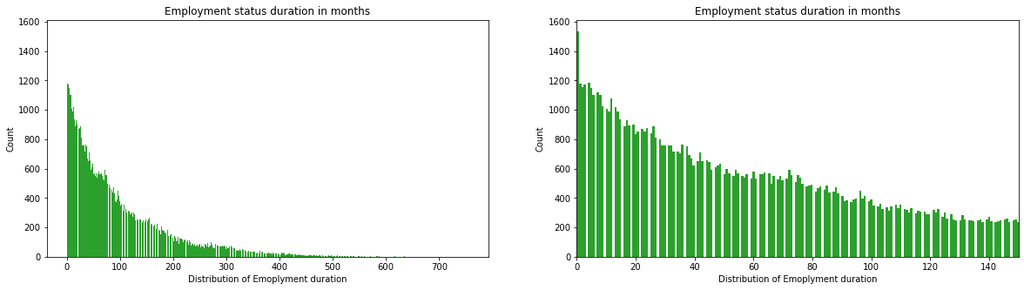

```python
# EMPLOYMENT STATUS DURATION review

plt.figure(figsize=[20,5])

plt.subplot(1,2,1)
bin_size=900
bins1=np.arange(0, (loans['EmploymentStatusDuration'].max())+bin_size, bin_size)
plt.hist(data=loans, x='EmploymentStatusDuration', color=base_color, bins=bin_size)

plt.xlabel('Distribution of Emoplyment duration')
plt.ylabel('Count')
plt.title('Employment status duration in months');

plt.subplot(1,2,2)
bin_size=1000
bins1=np.arange(0, (loans['EmploymentStatusDuration'].max())+bin_size, bin_size)
plt.hist(data=loans, x='EmploymentStatusDuration', color=base_color, bins=bin_size)

plt.xlim((0,150))
plt.xlabel('Distribution of Emoplyment duration')
plt.ylabel('Count')
plt.title('Employment status duration in months');
```

**Answer:** Employment status distribution seems reasonable. Even though majority of borrowers has shorter employment duration what is not in line with my previous expectation, no unusual items noticed.

##### Income Range

```python
# Review of INCOME RANGE
# The income range of the borrower at the time the listing was created.

# Set definition in order to create new column with ranges to easily plot bar chart
def income_range(x):
    if (x =='$1-24,999') :
        return '1-24,999'
    elif (x == '$25,000-49,999'):
        return '25,000-49,999'
    elif (x == '$50,000-74,999'):
        return '50,000-74,999'
    elif (x == '$75,000-99,999'):
        return '75,000-99,999'
    elif (x == '$100,000+'):
        return '100,000+'
    else:
        return 'Not available'


loans['Income_range_text'] = loans['IncomeRange'].apply(income_range)
loans.head(2)
```

|  | ListingKey | ListingNumber | ListingCreationDate | CreditGrade | Term | LoanStatus | ClosedDate | BorrowerAPR | BorrowerRate | LenderYield | EstimatedEffectiveYield | EstimatedLoss | EstimatedReturn | ProsperRating (numeric) | ProsperRating (Alpha) | ProsperScore | ListingCategory (numeric) | BorrowerState | Occupation | EmploymentStatus | EmploymentStatusDuration | IsBorrowerHomeowner | CurrentlyInGroup | GroupKey | DateCreditPulled | CreditScoreRangeLower | CreditScoreRangeUpper | FirstRecordedCreditLine | CurrentCreditLines | … |
| --- | --- | --- | --- | --- | --- | --- | --- | --- | --- | --- | --- | --- | --- | --- | --- | --- | --- | --- | --- | --- | --- | --- | --- | --- | --- | --- | --- | --- | --- | --- |
| 0 | 1021339766868145413AB3B | 193129 | 2007-08-26 19:09:29.263000000 | C | 36 | Completed | 2009-08-14 00:00:00 | 0.16516 | 0.158 | 0.138 | NaN | NaN | NaN | NaN | NaN | NaN | 0 | CO | Other | Self-employed | 2.0 | True | True | NaN | 2007-08-26 18:41:46.780000000 | 640.0 | 659.0 | 2001-10-11 00:00:00 | 5.0 | … |
| 1 | 10273602499503308B223C1 | 1209647 | 2014-02-27 08:28:07.900000000 | NaN | 36 | Current | NaN | 0.12016 | 0.092 | 0.082 | 0.0796 | 0.0249 | 0.0547 | 6.0 | A | 7.0 | 2 | CO | Professional | Employed | 44.0 | False | False | NaN | 2014-02-27 08:28:14 | 680.0 | 699.0 | 1996-03-18 00:00:00 | 14.0 | … |

```python
# Types of income range
income_range = ['1-24,999', '25,000-49,999', '50,000-74,999', '75,000-99,999', '100,000+', 'Not available']

# Returns the types for sedan_classes with the categories and orderedness
# Refer - https://pandas.pydata.org/pandas-docs/version/0.23.4/generated/pandas.api.types.CategoricalDtype.html
irange = pd.api.types.CategoricalDtype(ordered=True, categories=income_range)

# Use pandas.astype() to convert the "VClass" column from a plain object type into an ordered categorical type
loans['Income_range_text'] = loans['Income_range_text'].astype(irange);
```

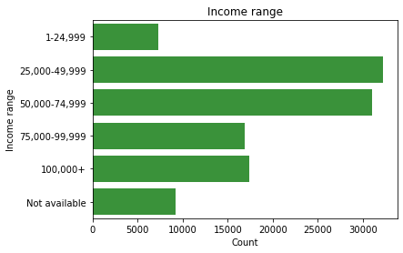

```python
# Plot for INCOME RANGE
sb.countplot(data=loans, y='Income_range_text', color=base_color, order=['1-24,999', '25,000-49,999', '50,000-74,999', '75,000-99,999', '100,000+', 'Not available'])
plt.xlabel('Count')
plt.ylabel('Income range')
plt.title('Income range');
```

**Answer:**

- Majority borrowers belong to income range USD 25,000-49,999, followed by income range USD 50,000-74,999 right after.
- The smallest group of borrowers belong to income range USD 1-24,999.
- Up to 10thousand observations (8,8%) have no information about income range of borrower.

##### Debt to Income Ratio

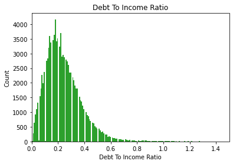

```python
# Review of DEBT TO INCOME RATIO

bin_size=1200
bins1=np.arange(0, (loans['DebtToIncomeRatio'].max())+bin_size, bin_size)
plt.hist(data=loans, x='DebtToIncomeRatio', color=base_color, bins=bin_size)

plt.xlim((0,1.5))
plt.xlabel('Debt To Income Ratio')
plt.ylabel('Count')
plt.title('Debt To Income Ratio');
```

```python
high_outliers=(loans['DebtToIncomeRatio'] > 1.2)

high_outliers.sum()
loans.loc[high_outliers,:].head(2)
```

|  | ListingKey | ListingNumber | ListingCreationDate | CreditGrade | Term | LoanStatus | ClosedDate | BorrowerAPR | BorrowerRate | LenderYield | EstimatedEffectiveYield | EstimatedLoss | EstimatedReturn | ProsperRating (numeric) | ProsperRating (Alpha) | ProsperScore | ListingCategory (numeric) | BorrowerState | Occupation | EmploymentStatus | EmploymentStatusDuration | IsBorrowerHomeowner | CurrentlyInGroup | GroupKey | DateCreditPulled | CreditScoreRangeLower | CreditScoreRangeUpper | FirstRecordedCreditLine | CurrentCreditLines | … |
| --- | --- | --- | --- | --- | --- | --- | --- | --- | --- | --- | --- | --- | --- | --- | --- | --- | --- | --- | --- | --- | --- | --- | --- | --- | --- | --- | --- | --- | --- | --- |
| 22 | 101735700321773921526BF | 706927 | 2013-01-30 09:36:13.783000000 | NaN | 36 | Current | NaN | 0.35356 | 0.3134 | 0.3034 | 0.276 | 0.1575 | 0.1185 | 1.0 | HR | 2.0 | 1 | NY | Other | Other | 68.0 | False | False | NaN | 2013-01-30 09:36:09 | 700.0 | 719.0 | 1988-03-01 00:00:00 | 9.0 | … |
| 226 | 2EA63382419173023274969 | 104542 | 2007-02-28 10:45:44.153000000 | D | 36 | Completed | 2009-07-07 00:00:00 | 0.11749 | 0.1000 | 0.0900 | NaN | NaN | NaN | NaN | NaN | NaN | 0 | NY | Other | Full-time | 9.0 | True | True | E3F433654060844916DB34F | 2007-02-28 10:31:56.417000000 | 600.0 | 619.0 | 1987-05-01 00:00:00 | 30.0 | … |

##### Recomendations

```python
# Preparation for RECOMENDATION review
order_recom=loans['Recommendations'].value_counts()[0:3]
```

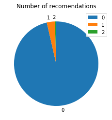

```python
# RECOMENDATION review using pie plot

plt.pie(order_recom, labels=order_recom.index, startangle=90, counterclock=False)
plt.legend()
plt.title('Number of recomendations');
```

**Answer:** Majority of borrowers has no recomendations, excpet to small amount of borrowers who had 1 or 2 recommendations.

Questions to discuss:

- Discuss the distribution(s) of your variable(s) of interest. Were there any unusual points? Did you need to perform any transformations?
- Of the features you investigated, were there any unusual distributions? Did you perform any operations on the data to tidy, adjust, or change the form of the data? If so, why did you do this?

## Bivariate Exploration

I will focus mainly on variable *'Loan Amount'* and its relationship with other selected quantitative variables *'Borrower Rate', 'Term conditions', 'Prosper Score'* and qualitative variables *'Income Range', 'Listing Categories'*. I will shortly look at relationship between *'Income range'* and *'Term conditions'*.

##### Relationship between Loan Amount and Borrower rate

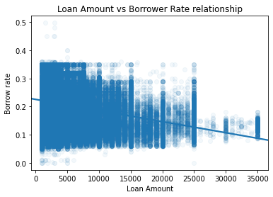

```python
# Plot scatter plot to see relationship between Borrower rate and Loan Amount
sb.regplot(data=loans, x='LoanOriginalAmount', y='BorrowerRate', truncate=False, x_jitter=0.3,scatter_kws={'alpha':1/20})
plt.xlabel('Loan Amount')
plt.ylabel('Borrow rate')
plt.title('Loan Amount vs Borrower Rate relationship');
```

**Answer:** According to expectation, the correlation between these two variables is negative.

##### Relationship between Loan Amount and Term conditions

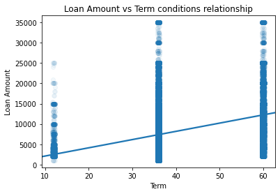

```python
# Plot scatter plot to see relationship between Term conditions and Loan Amount
sb.regplot(data=loans, x='Term', y='LoanOriginalAmount',truncate=False, x_jitter=0.3,scatter_kws={'alpha':1/20})
plt.xlabel('Term')
plt.ylabel('Loan Amount')
plt.title('Loan Amount vs Term conditions relationship');
```

**Answer:** There is weak correlation relationship. Loans for short term period seem to have lower amount( up to 10 thousand). Some points show higher amounts (20 and 25 thousand) - possibly outliers. The periods of 36 and 60 seem to be comparable. Higher loan amounts are dedicated to longer period.

##### Relationship between Loan Amount and Income Range

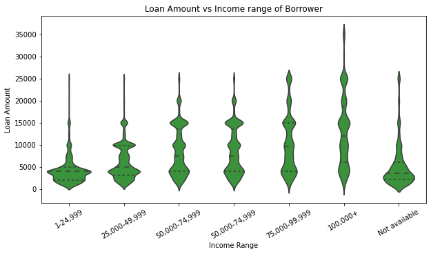

```python
# Plot violin chart to capture distribution of Loan Amount among Income ranges

plt.figure(figsize=[10,5])
sb.color_palette()[0]
sb.violinplot(data=loans, x='Income_range_text', y='LoanOriginalAmount', color=base_color, inner='quartile', order=['1-24,999', '25,000-49,999', '50,000-74,999', '50,000-74,999','75,000-99,999', '100,000+', 'Not available'])
plt.xticks(rotation=30)
plt.title('Loan Amount vs Income range of Borrower')
plt.xlabel('Income Range')
plt.ylabel('Loan Amount');
```

**Answer:** The plot seems reasonable, the mean increases in line with increase in income. I noticed that peaks in distributions probably refer to standard loan amounts (5,000; 10,000; 15,000, 25,000). There are 10thousand observation which have not available data, as already discussed in Part I.

##### Relationship between Income Range and Term conditions

```python
ct_counts = loans.groupby(['Income_range_text', 'Term']).size()[0:15]
ct_counts
```

```
Income_range_text  Term
1-24,999           12         77
                   36       6409
                   60        788
25,000-49,999      12        381
                   36      25485
                   60       6326
50,000-74,999      12        432
                   36      22682
                   60       7936
75,000-99,999      12        311
                   36      12028
                   60       4577
100,000+           12        387
                   36      12150
                   60       4800
dtype: int64
```

```python
ct_counts = ct_counts.reset_index(name='count')
ct_counts
```

|  | Income_range_text | Term | count |
| --- | --- | --- | --- |
| 0 | 1-24,999 | 12 | 77 |
| 1 | 1-24,999 | 36 | 6409 |
| 2 | 1-24,999 | 60 | 788 |
| 3 | 25,000-49,999 | 12 | 381 |
| 4 | 25,000-49,999 | 36 | 25485 |
| 5 | 25,000-49,999 | 60 | 6326 |
| 6 | 50,000-74,999 | 12 | 432 |
| 7 | 50,000-74,999 | 36 | 22682 |
| 8 | 50,000-74,999 | 60 | 7936 |
| 9 | 75,000-99,999 | 12 | 311 |
| 10 | 75,000-99,999 | 36 | 12028 |
| 11 | 75,000-99,999 | 60 | 4577 |
| 12 | 100,000+ | 12 | 387 |
| 13 | 100,000+ | 36 | 12150 |
| 14 | 100,000+ | 60 | 4800 |

```python
ct_counts = ct_counts.pivot(index = 'Income_range_text', columns = 'Term', values = 'count')
ct_counts
```

| Term Income_range_text | 12 | 36 | 60 |
| --- | --- | --- | --- |
| 1-24,999 | 77 | 6409 | 788 |
| 25,000-49,999 | 381 | 25485 | 6326 |
| 50,000-74,999 | 432 | 22682 | 7936 |
| 75,000-99,999 | 311 | 12028 | 4577 |
| 100,000+ | 387 | 12150 | 4800 |

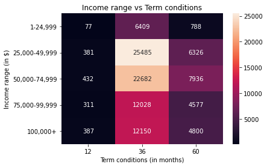

```python
sb.heatmap(ct_counts, annot=True, fmt='.0f')
plt.xlabel('Term conditions (in months)')
plt.ylabel('Income range (in $)')
plt.title('Income range vs Term conditions');
```

**Answer:**

- Based on the heatmap plotted, we may conclude that, the most number of loans were borrowed for 36 months period to borrowers from income range USD 25,000-49,999 followed by income range USD 50,000-74,999.
- The lease number of loans were borrowed for 12 months period to borrowers from income range USD 1-24,999.

##### Relationship between Loan Amount and Listing Category

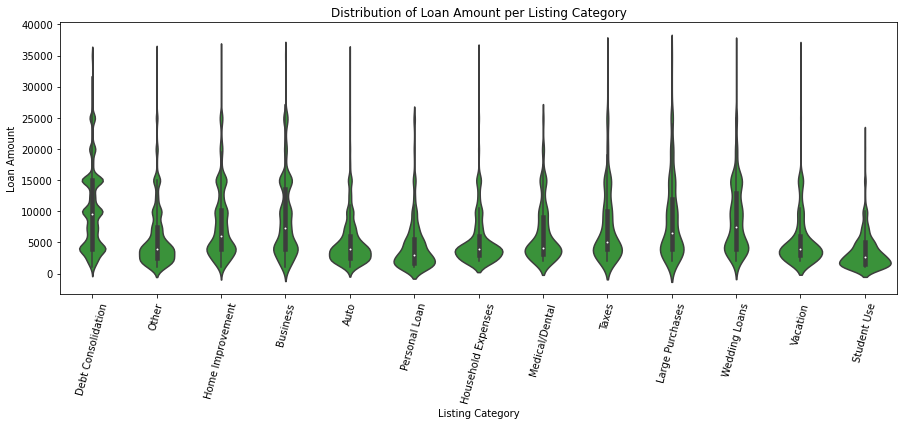

```python
plt.figure(figsize=[15,5])
sb.violinplot(data=loans_without_nan, y='LoanOriginalAmount', x='ListingCategory_text', color=base_color, order=order_without_nan.index, innner=None)
plt.xticks(rotation=75)
plt.xlabel('Listing Category')
plt.ylabel('Loan Amount')
plt.title('Distribution of Loan Amount per Listing Category');
```

**Answer:**

- The lowest median value is seen in Student use, Personal Loan and Vacation assuming that only small value loans are popular. This assumption is supported by distribution on the graph, which is quite high around median (lower than USD 5,000)
- The highest median value is seen in Debt Consolidation (higher disttribution around standard Loan amounts as of USD 5,000; USD 10,000 and USD 15,000) and Wedding Loans.

Questions to discuss:

###### Talk about some of the relationships you observed in this part of the investigation. How did the feature(s) of interest vary with other features in the dataset?

###### Did you observe any interesting relationships between the other features (not the main feature(s) of interest)?

Refer to Conclusion below.

### Conclusion

- According to expectations, the correlation between Loan Amount and Borrower rate is negative.
- There is weak correlation relationship between Loan Amount and Term period. Loans for short term period seem to have lower amount ( up to USD 10 thousand). Some points in the graph show much higher amounts (USD 20 and 25 thousand), we may consider them as outliers. The periods of 36 and 60 months seem to be rather comparable. Higher loan amounts seem to be borrowed for longer periods.
- Based on the heatmap plotted, we may conclude that, the most number of loans were borrowed by borrowers from income range USD 25,000-49,999 for 36 months period, followed by borrowers from income range USD 50,000-74,999.
- The lease number of loans were borrowed by borrowers from income range USD 1-24,999 for 12 months period.
- The lowest median value is seen in listing categories Student use, Personal Loan and Vacation assuming that only small value loans are popular. This assumption is supported by distribution on the graph, which is quite high around median (lower than USD 5,000)
- The highest median value is seen in Debt Consolidation (higher disttribution around standard Loan amounts as of USD 5,000; USD 10,000 and USD 15,000) and Wedding Loans.

## Multivariate Exploration

During multivariate exploration I will focus on three parts as follows:

##### Relationship between Loan Amount, Borrower Rate/APR and Lender Yield

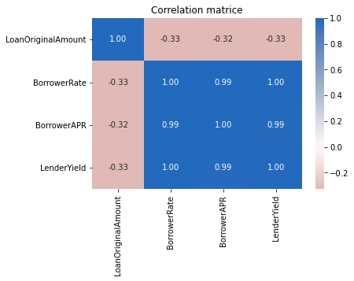

```python
# Learn correlation relationship between Loan Amount, Borrower Rate/APR and Lender Yield
sb.heatmap(loans[['LoanOriginalAmount', 'BorrowerRate', 'BorrowerAPR', 'LenderYield']].corr(), annot = True, fmt = '.2f', cmap = 'vlag_r', center = 0)
plt.title('Correlation matrice')
```

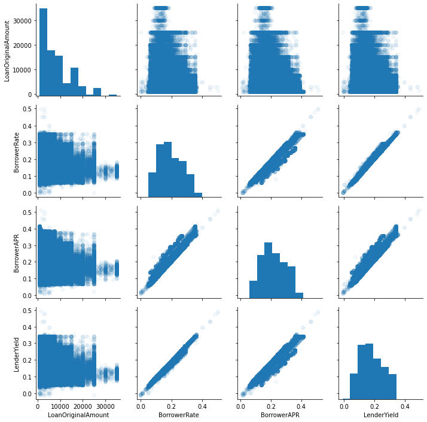

```python
# Plot matrices for selected variables
variables=['LoanOriginalAmount', 'BorrowerRate', 'BorrowerAPR', 'LenderYield']
g=sb.PairGrid(data=loans, vars=variables)
g=g.map_offdiag(plt.scatter, alpha=1/20);
g.map_diag(plt.hist);
```

**Answer:** As I see at heatmap, there is negative correlation between Borrower rate and Loan Amount, supporting the general knowleadge, that high amount of loan is connected to lower interest rate (while taking into consideration loan period). I can see strong correlation between Borrower rate and Borrower APR as these are comparable variables. Both correlate to Lender Yield, as it is actually borrower interest rate but without service fee. Borrower rate is connected 'Borrower - Client' and Lender Yield is on the other hand connected to 'Bank-Company'.

##### Relationship between Loan amount, Listing category and Borrow rate

```python
# Create dataset with Category listing over 1000 observations
loans1=loans_without_nan.loc[(loans_without_nan['ListingCategory_text']=='Debt Consolidation') | (loans_without_nan['ListingCategory_text']=='Other')| (loans_without_nan['ListingCategory_text']=='Home Improvement')| (loans_without_nan['ListingCategory_text']=='Business')|(loans_without_nan['ListingCategory_text']=='Auto')|(loans_without_nan['ListingCategory_text']=='Personal loan')|(loans_without_nan['ListingCategory_text']=='Household Expenses')|(loans_without_nan['ListingCategory_text']=='Medical/Dental')]
```

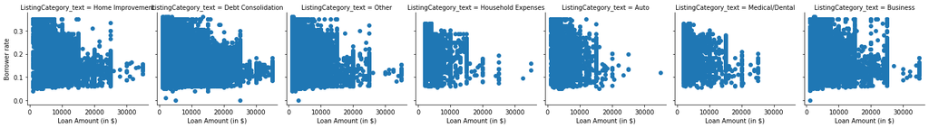

```python
# Faceting for multi data
g = sb.FacetGrid(data = loans1, col = 'ListingCategory_text', size = 3,
                margin_titles = True)
g.map(plt.scatter, 'LoanOriginalAmount', 'BorrowerRate')

g.set_xlabels('Loan Amount (in $)')
g.set_ylabels('Borrower rate');
```

**Answer:** As I see, there is negative correlation between Loan Amount (within each listing category) and Borrower Rate. We may notice a few visible outliers in category Household Expenses and Auto (loan amount over 30,000).

##### Relationship between Income range, Listing Category and Loan amount

```python
# Use definition to add Income range column to new dataset loan2
def income_range(x):
    if (x =='$1-24,999') :
        return '1-24,999'
    elif (x == '$25,000-49,999'):
        return '25,000-49,999'
    elif (x == '$50,000-74,999'):
        return '50,000-74,999'
    elif (x == '$75,000-99,999'):
        return '75,000-99,999'
    elif (x == '$100,000+'):
        return '100,000+'
    else:
        return 'Not available'
```

```python
# Create dataset with Category listing over 1000 observations for dataset loan2
loans2=loans_without_nan.loc[(loans_without_nan['ListingCategory_text']=='Debt Consolidation') | (loans_without_nan['ListingCategory_text']=='Other')| (loans_without_nan['ListingCategory_text']=='Home Improvement')]


loans2['Income_range_text'] = loans2['IncomeRange'].apply(income_range)
```

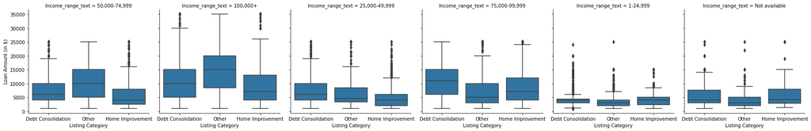

```python
g = sb.FacetGrid(data = loans2, col = 'Income_range_text', size = 4)
g.map(sb.boxplot, 'ListingCategory_text', 'LoanOriginalAmount')

g.set_xlabels('Listing Category')
g.set_ylabels('Loan Amount (in $)');
```

**Answer:**

##### Further analysis of specific range of Lender Yield from Part I

```python
# Noticeable spike review in detail (0.3-0.32), original histogram plotted in Part I
noticeable_spike = (loans1['LenderYield'] > 0.3) & (loans1['LenderYield'] < 0.32)
noticeable_spike.sum()
b_rate_review=loans1.loc[noticeable_spike,:]
```

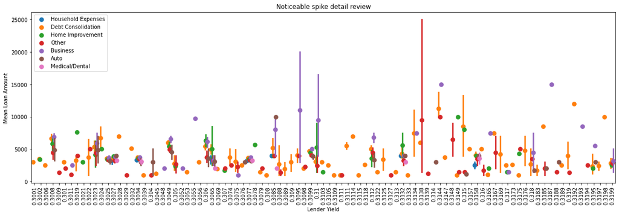

```python
# I will plot pointplot to see relationship between Loan Amount, Lender Yield and Listing category
fig = plt.figure(figsize = [20,6])
ax = sb.pointplot(data = b_rate_review, x = 'LenderYield', y = 'LoanOriginalAmount', hue = 'ListingCategory_text',
           linestyles = '', dodge = 0.8)

plt.title('Noticeable spike detail review',)
plt.ylabel('Mean Loan Amount')
plt.xlabel('Lender Yield')
plt.xticks(rotation=90)

plt.legend(loc="upper left")
plt.show();
```

### Conclusion

```python
# Save to csv
loans.to_csv('loans1.csv')
loans1.to_csv('loans2.csv')
loans2.to_csv('loans3.csv')
```